# Domínios de Natureza e Paisagens Tropicais

Análise da Paisagem · Aula 2.2

Prof. Dr. Luiz Diego Vidal Santos

## Visão Geral da Aula

### Tópicos

- 1 O conceito de Geossistema na tradição franco-brasileira
- 2 Bertrand (1971): taxonomia da paisagem
- 3 Monteiro (1976/2000): geossistemas no Brasil
- 4 Ab’Sáber (2003): domínios de natureza
- 5 Aplicação: paisagens do semiárido baiano
- 6 Exercício: identificação de domínios morfoclimáticos

**Objetivo da Aula**

Compreender as bases conceituais dos **geossistemas** e dos **domínios de natureza** como modelos de classificação e análise da paisagem brasileira, com ênfase na escola geográfica franco-brasileira.

# O GEOSSISTEMA: ORIGEM E EVOLUÇÃO

## De Sochava a Bertrand

O conceito de **geossistema** surgiu na escola soviética com Viktor Sochava (1963), que propôs tratar a paisagem como um sistema natural total, integrando litosfera, atmosfera, hidrosfera e biosfera.

Georges **Bertrand** (1971) reformulou o conceito para a tradição francesa, acrescentando a **ação antrópica** como componente estruturante do geossistema e propondo uma **taxonomia hierárquica** das unidades de paisagem.

> *“A paisagem não é a simples adição de elementos geográficos disparatados, é, em uma determinada porção do espaço, o resultado da combinação dinâmica, portanto instável, de elementos físicos, biológicos e antrópicos.”*

> (Bertrand, 1971)

**Referência Fundamental**

**BERTRAND, G.** (1971). Paysage et géographie physique globale: esquisse méthodologique. *Rev. Géogr. Pyrénées SO*, **39**(3), 249-272.

Tradução brasileira em *RA’E GA*, v. 8, 2004.

## Taxonomia das Unidades de Paisagem

Bertrand propôs seis níveis taxonômicos hierárquicos para classificar as unidades de paisagem:

Taxonomia hierárquica de Bertrand (1971).

| Nível | Unidade | Escala | Exemplo |
| --- | --- | --- | --- |
| I | Zona | 10⁷-10⁸ ha | Zona tropical, zona temperada |
| II | Domínio | 10⁶-10⁷ ha | Domínio das caatingas |
| III | Região natural | 10⁵-10⁶ ha | Depressão sertaneja |
| IV | **Geossistema** | 10³-10⁵ ha | Pediplano cristalino com caatinga arbórea |
| V | Geofácies | 10¹-10³ ha | Vertente com solo raso e vegetação aberta |
| VI | Geótopo | < 10¹ ha | Afloramento rochoso com liquens |

**Nota**

O **geossistema** é a unidade central de análise (escala compatível com bacias de 3ª-5ª ordem), onde a interação entre componentes é mais perceptível pela ação humana.

## Tripé do Geossistema

Bertrand concebeu o geossistema como a interação de três componentes:

[figure not shown]

A retroalimentação entre ação antrópica e potencial ecológico é o que diferencia o geossistema de um simples ecossistema (a **sociedade** é vista como componente interno, não externo).

**Ciclo de retroalimentação**

**Potencial Ecológico** dá suporte à **Exploração Biológica**, que sofre **transformação** pela **Ação Antrópica**, cujo **impacto** recai sobre o Potencial Ecológico.

# MONTEIRO: GEOSSISTEMAS NO BRASIL

## Carlos Augusto de Figueiredo Monteiro

Monteiro (1976, 2000) adaptou o conceito de geossistema à realidade brasileira, enfatizando:

- A **dinâmica climática** como motor de diferenciação paisagística no Brasil
- A necessidade de integrar dados **quantitativos** (climatológicos, hidrológicos) com análise **qualitativa** (uso da terra, percepção)
- O conceito de **derivações antropogênicas**: transformações impostas pela sociedade sobre o sistema natural

Monteiro introduziu o termo **geossistema urbano** para cidades brasileiras, ampliando o conceito para além das paisagens rurais/naturais.

**Referência**

**MONTEIRO, C.A.F.** (2000). *Geossistemas: a história de uma procura*. São Paulo: Contexto.

## Derivações Antropogênicas

Monteiro classificou as derivações antropogênicas em três tipos:

Tipos de derivações antropogênicas (Monteiro, 2000).

| Tipo de derivação | Descrição | Exemplo no Semiárido |
| --- | --- | --- |
| **Supressão** | Remoção de componentes do sistema | Desmatamento da caatinga para pecuária |
| **Inserção** | Introdução de componentes exógenos | Irrigação em áreas de sequeiro; espécies exóticas |
| **Alteração funcional** | Mudança nos fluxos e nos ritmos | Barramento de rios; urbanização de várzeas |

Essas derivações **acumulam-se no tempo**, criando trajetórias de degradação ou de recuperação que só são compreensíveis na perspectiva do geossistema.

## Exemplos de Derivações Antropogênicas

### Supressão

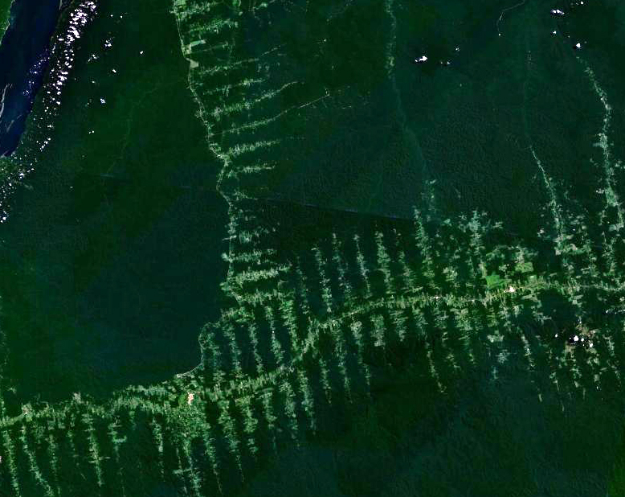

Desmatamento em “espinha de peixe” na Amazônia, padrão associado à abertura de ramais para pecuária extensiva

[figure not shown]

Queimada em floresta tropical, técnica de remoção por fogo que elimina biomassa e altera os ciclos biogeoquímicos do solo

[figure not shown]

Solo degradado após supressão da cobertura vegetal, com perda de matéria orgânica e exposição a processos erosivos

### Inserção

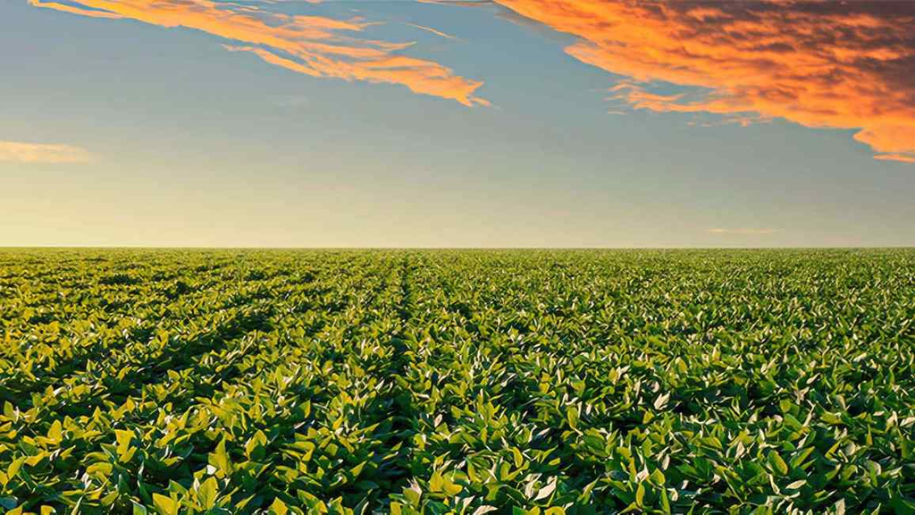

Monocultura de soja em larga escala, exemplo de inserção de componente exógeno em substituição à vegetação nativa

[figure not shown]

Expansão agrícola no MATOPIBA (Cerrado), onde a inserção de pivôs de irrigação e cultivos mecanizados transforma a estrutura superficial da paisagem

### Alteração funcional

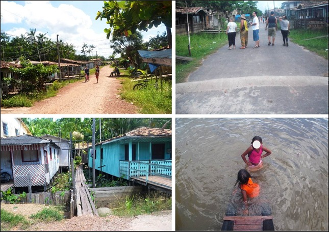

Expansão urbana sobre áreas rurais e de várzea, alterando fluxos hídricos, regimes térmicos e conectividade ecológica

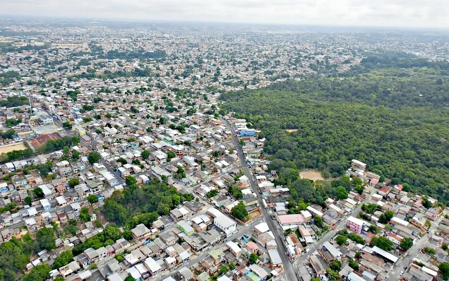

Vista aérea de cidade, onde a impermeabilização do solo e a canalização de cursos d’água reconfiguram o geossistema original

**Acúmulo de derivações**

Na prática, as três formas de derivação frequentemente coocorrem em uma mesma paisagem. O desmatamento (supressão) precede a introdução de pastagens exóticas (inserção), que por sua vez modifica o balanço hídrico e os regimes de escoamento (alteração funcional), configurando trajetórias de degradação cumulativa.

# AB’SÁBER: DOMÍNIOS DE NATUREZA

## Os Domínios Morfoclimáticos

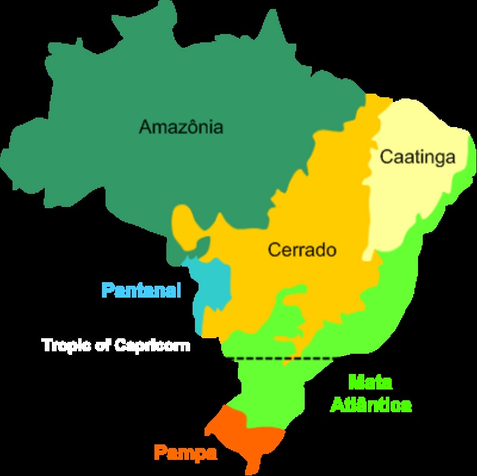

Mapa dos domínios morfoclimáticos / biomas do Brasil

Aziz **Ab’Sáber** (2003) sintetizou décadas de pesquisa geomorfológica em uma classificação das grandes paisagens brasileiras em **seis domínios morfoclimáticos**:

1. **Amazônico** (terras baixas florestadas)
2. **Cerrado** (chapadões tropicais com cerrados e florestas-galeria)
3. **Mares de Morros** (relevo mamelonizado com Mata Atlântica)
4. **Caatingas** (depressões interplanálticas semiáridas)
5. **Araucárias** (planalto meridional com floresta mista)
6. **Pradarias** (campos do sul com coxilhas)

Entre os domínios situam-se as **faixas de transição** (*ecótonos macro-regionais*), onde as características se interpenetram.

**Referência Fundamental**

**AB’SÁBER, A.N.** (2003). *Os domínios de natureza no Brasil: potencialidades paisagísticas*. São Paulo: Ateliê Editorial.

## Três Níveis de Compreensão

Ab’Sáber propôs três **níveis taxonômicos** de leitura do meio ambiente:

Três níveis de compreensão do meio ambiente (Ab’Sáber, 2003).

| Nível | Acesso | O que revela |
| --- | --- | --- |
| 1º | **Compartimentação topográfica** | Formas de relevo regional (planaltos, depressões, planícies) |
| 2º | **Estrutura superficial da paisagem** | Solos, formações superficiais, mantos de intemperismo |
| 3º | **Fisiologia da paisagem** | Dinâmica climática, hidrológica e ecológica atual |

O 3º nível (**fisiologia da paisagem**) corresponde à dinâmica dos processos atuais e é o mais suscetível às derivações antropogênicas de Monteiro.

## Domínio das Caatingas e o Semiárido Baiano

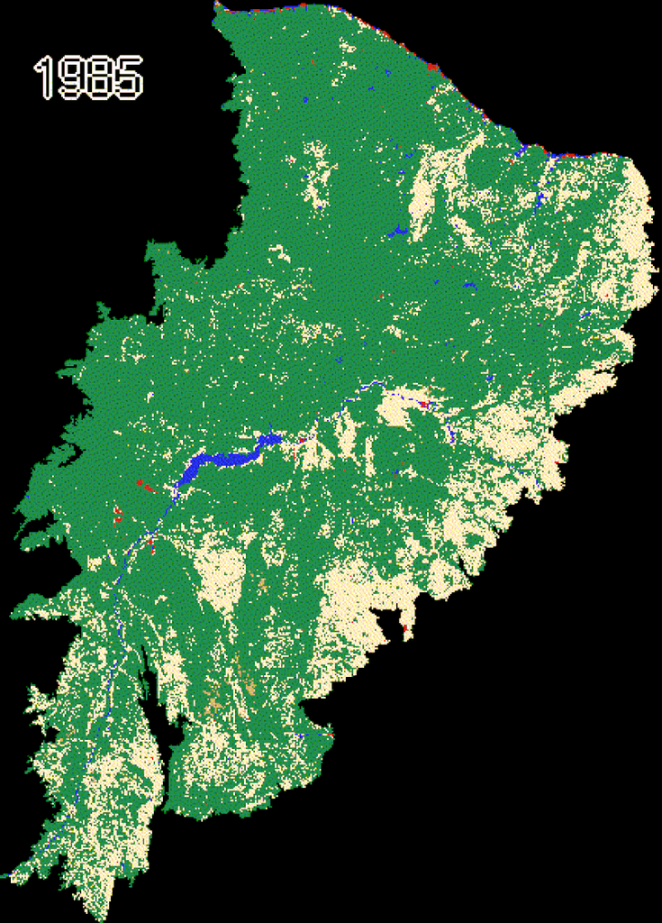

Vegetação da Caatinga no semiárido nordestino

Síntese do domínio das Caatingas (Ab’Sáber, 2003).

| Atributo | Caracterização |
| --- | --- |
| **Relevo** | Depressões interplanálticas, 200-500 m |
| **Clima** | BSh (Köppen), P < 800 mm/ano, chuvas em 3-5 meses |
| **Solos** | Rasos (Neossolos Litólicos, Luvissolos) |
| **Vegetação** | Caducifólia, arbustiva a arbórea |
| **Paleoclimas** | Evidências de períodos mais úmidos (enclaves de mata) |

**Expressões regionais na Bahia**

A **Bacia do Paraguaçu** marca a transição Caatinga-Mata Atlântica. A **Chapada Diamantina** funciona como refúgio de altitude, abrigando campos rupestres. No extremo oposto, o **Raso da Catarina** representa a caatinga hiperxerófila em sua expressão mais restritiva.

## Chapada Diamantina: Refúgio de Altitude

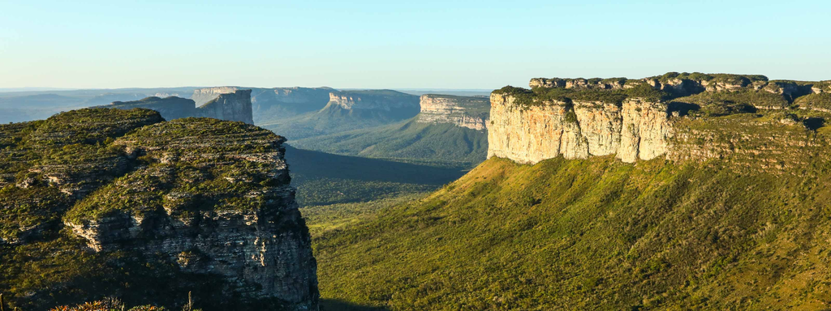

Vista panorâmica da Chapada Diamantina, planalto elevado que rompe a homogeneidade das depressões semiáridas

No modelo de Ab’Sáber, a **Chapada Diamantina** é classificada como um **enclave** e **refúgio de altitude** dentro do Domínio das Caatingas.

A existência desse refúgio é evidência dos **paleoclimas** mais úmidos que modelaram a paisagem brasileira.

## Chapada Diamantina nos Três Níveis de Ab’Sáber

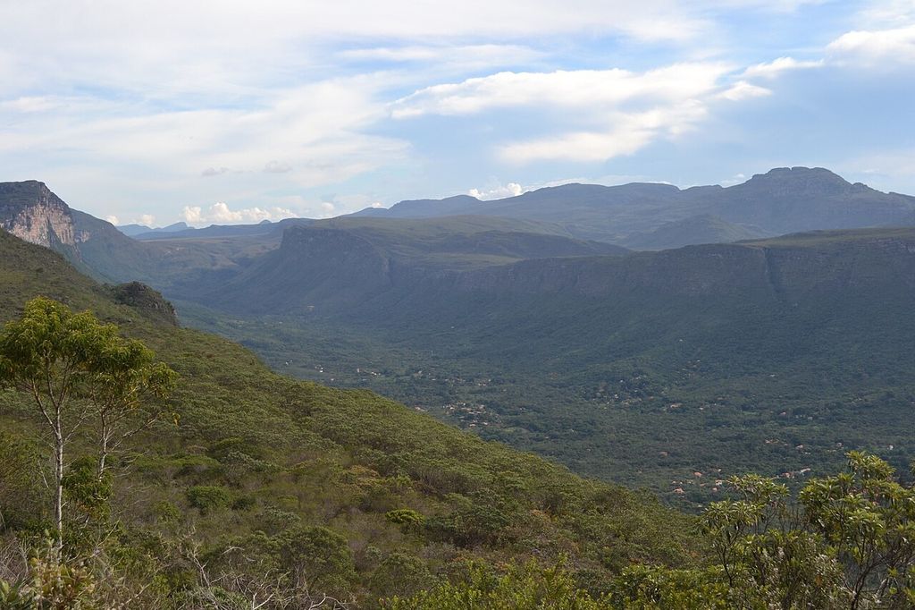

Paisagem de campo rupestre na Chapada Diamantina, com vegetação adaptada a solos quartzíticos de altitude

Três níveis de compreensão aplicados à Chapada Diamantina.

| Nível de Ab’Sáber | Aplicação à Chapada Diamantina |
| --- | --- |
| **1º - Compartimentação topográfica** | Planalto elevado (> 800 m) que se destaca das depressões interplanálticas circundantes (200-500 m) |
| **2º - Estrutura superficial** | Solos quartzíticos com campos rupestres, diferindo dos Neossolos Litólicos e Luvissolos típicos do núcleo das Caatingas |
| **3º - Fisiologia da paisagem** | Dinâmica climática e ecológica própria: maior umidade, refúgio hídrico e biológico para a região |

**Implicação prática**

A Chapada Diamantina funciona como **“pulmão” hídrico** do semiárido baiano. A Bacia do Paraguaçu, que nasce na Chapada, é a principal fonte de abastecimento de Salvador e Recôncavo.

## Chapada Diamantina na Taxonomia de Bertrand

Aplicando a hierarquia de Bertrand (1971) à Chapada Diamantina:

Enquadramento da Chapada Diamantina na taxonomia de Bertrand.

| Nível de Bertrand | Unidade | Enquadramento da Chapada |
| --- | --- | --- |
| **II - Domínio** | Domínio das Caatingas | Inserida no contexto macro do semiárido nordestino |
| **III - Região Natural** | Chapada Diamantina | Região natural específica, distinta da Depressão Sertaneja, pela fisiografia de planalto com campos rupestres |
| **IV - Geossistema** | Subunidades internas | Vales (Pati, Capão), setores de planalto, áreas de uso turístico e agrícola, onde a interação potencial ecológico × ação antrópica é perceptível |

**Convergência dos modelos**

A Chapada Diamantina ilustra a **complementaridade** entre Ab’Sáber e Bertrand: o enquadramento macro (domínio) é dado por Ab’Sáber, mas a análise operacional das unidades internas (geossistemas, geofácies) requer a taxonomia de Bertrand. As **derivações antropogênicas** de Monteiro (turismo, garimpo histórico, agricultura de altitude) explicam as trajetórias de transformação da paisagem.

# SÍNTESE E CONEXÕES

## Bertrand × Monteiro × Ab’Sáber

Comparação entre as três abordagens.

| Aspecto | Bertrand (1971) | Monteiro (2000) | Ab’Sáber (2003) |
| --- | --- | --- | --- |
| **Unidade central** | Geossistema | Geossistema urbano/rural | Domínio morfoclimático |
| **Escala** | 10³-10⁵ ha | 10⁴-10⁶ ha | 10⁶-10⁷ ha |
| **Ênfase** | Taxonomia + ação antrópica | Derivações + clima | Geomorfologia + paleoclima |
| **Força** | Modelo integrador operacional | Aplicação brasileira | Visão continental |
| **Limitação** | Pouco quantitativo | Dados difíceis de escalar | Baixa resolução local |

As três abordagens são **complementares**: Ab’Sáber define o enquadramento macro, Bertrand fornece a taxonomia operacional e Monteiro insere a dinâmica temporal e antrópica.

## Uma Metáfora para Lembrar

Pense na paisagem como uma **peça de teatro**:

A metáfora teatral dos três autores.

| Autor | Papel na metáfora | O que fornece |
| --- | --- | --- |
| **Ab’Sáber** | O **palco** | Define o cenário continental: relevo, clima, domínios morfoclimáticos. É a estrutura fixa sobre a qual tudo acontece. |
| **Bertrand** | O **roteiro local** | Organiza a cena em atos e escalas (zona → domínio → geossistema → geótopo). Descreve como os componentes interagem em cada nível. |
| **Monteiro** | As **ações do ator principal** (a humanidade) | Mostra o que o protagonista faz com o palco: suprime, insere, altera. São as derivações antropogênicas que transformam a paisagem ao longo do tempo. |

**Síntese**

Sem o **palco** (Ab’Sáber) não há onde atuar. Sem o **roteiro** (Bertrand) não se sabe a escala da cena. Sem reconhecer as **ações do ator** (Monteiro), não se compreende por que a paisagem muda.

## Conexão com a Disciplina

### Para cima (escalas maiores)

- Os domínios de Ab’Sáber contextualizam a **paisagem regional**
- Determinam o **potencial ecológico** de base

### Para baixo (escalas menores)

- Geossistema → geofácies → geótopo de Bertrand
- Conecta-se às **métricas FRAGSTATS** aplicadas em nível de mancha

### Para a prática

- **Diagnóstico integrado** (Aula 20) utiliza os 3 níveis de Ab’Sáber
- **Zoneamento geoambiental** (Aula 22) aplica a taxonomia de Bertrand
- **Trabalho de campo** (Aula 25) coleta dados para validar a fisiologia da paisagem

## Leituras Recomendadas

- **BERTRAND, G.** (1971). Paysage et géographie physique globale. *Rev. Géogr. Pyrénées SO*, 39(3), 249-272.
- **MONTEIRO, C.A.F.** (2000). *Geossistemas: a história de uma procura*. São Paulo: Contexto.
- **AB’SÁBER, A.N.** (2003). *Os domínios de natureza no Brasil*. São Paulo: Ateliê Editorial.
- **METZGER, J.P.** (2001). O que é ecologia de paisagens? *Biota Neotropica*, 1(1), 1-9.

# EXERCÍCIO

## Exercício Orientado, Três Níveis de Ab’Sáber

Aplique os três níveis de compreensão de Ab’Sáber à sua área de estudo, utilizando **Google Earth Engine** ou **QGIS**:

Roteiro de aplicação dos três níveis de Ab’Sáber.

| Etapa | Nível de Ab’Sáber | Procedimento |
| --- | --- | --- |
| 1 | **Compartimentação topográfica** (1º) | Delimitar planaltos, depressões e planícies a partir de MDE (SRTM/ALOS) |
| 2 | **Estrutura superficial** (2º) | Sobrepor mapas de solo e cobertura vegetal (MapBiomas / IBGE) |
| 3 | **Fisiologia da paisagem** (3º) | Analisar séries NDVI (12 meses) para capturar a dinâmica fenológica |
| 4 | **Enquadramento** | Identificar qual domínio ou faixa de transição a área representa |

**Dica**

Compare os padrões de NDVI entre estação seca e chuvosa. No domínio das Caatingas, a amplitude é tipicamente > 0,3, refletindo a deciduidade da vegetação.